# Supervised Learning - Foundations Project: ReCell

## EDA

- It is a good idea to explore the data once again after manipulating it.

### Univariate Analysis of Numerical Features

**`normalized_used_price`**

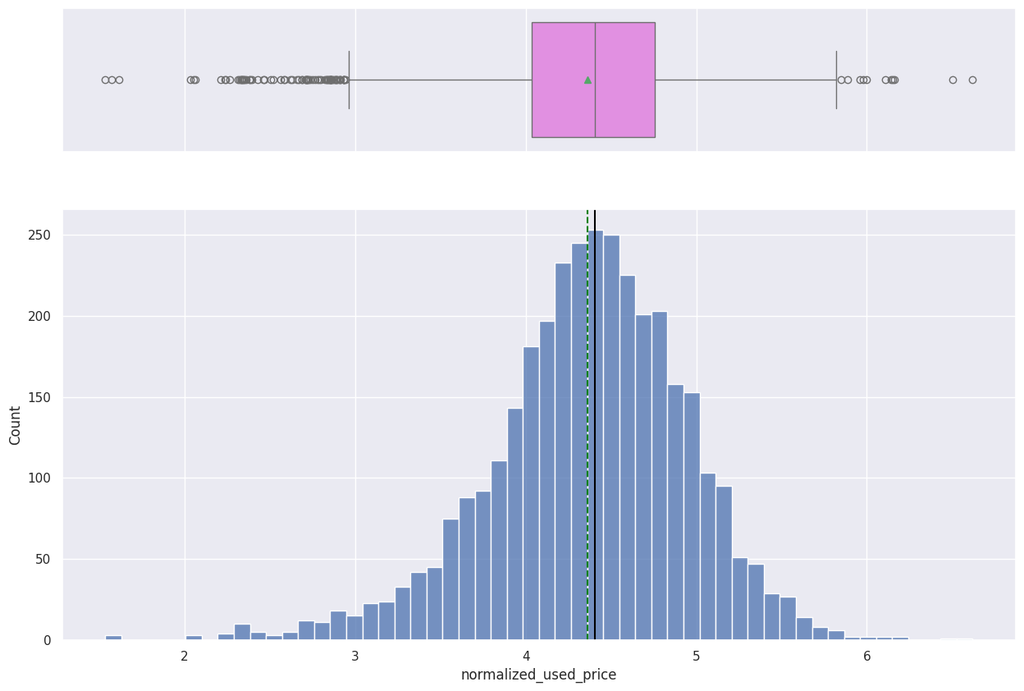

```python
histogram_boxplot(df1, "normalized_used_price")
```

**Observation:**

- The distribution of normalized used device prices still appears slightly skewed to the left.
- The range and concentration of prices remain similar after preprocessing.

**`normalized_new_price`**

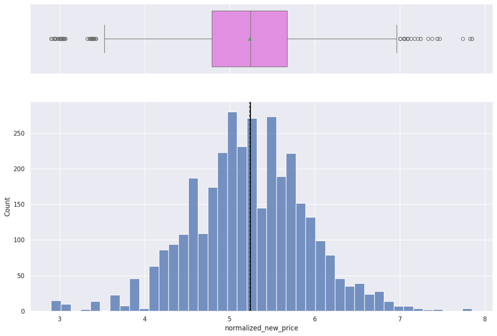

```python
histogram_boxplot(df1, "normalized_new_price")
```

**Observation:**

- The distribution of normalized new prices is similar to before preprocessing.

**`screen_size`**

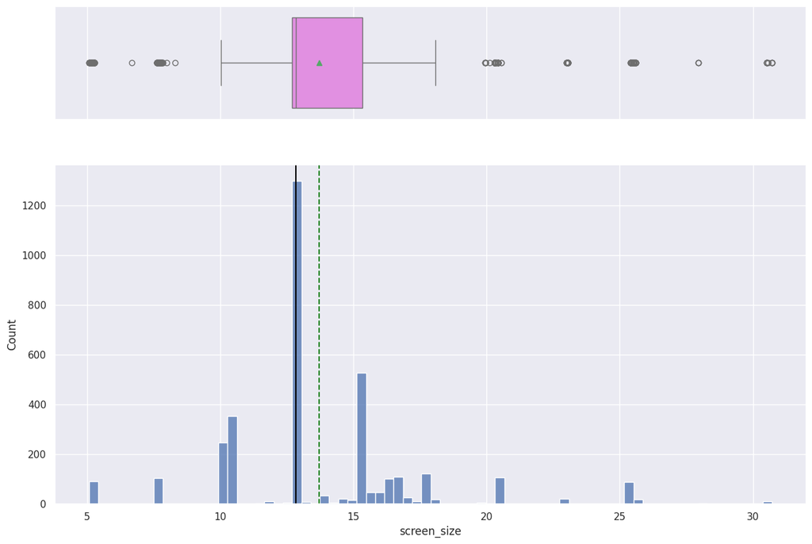

```python
histogram_boxplot(df1, "screen_size")
```

**Observation:**

- The distribution of screen size remains largely the same after preprocessing.

**`main_camera_mp`**

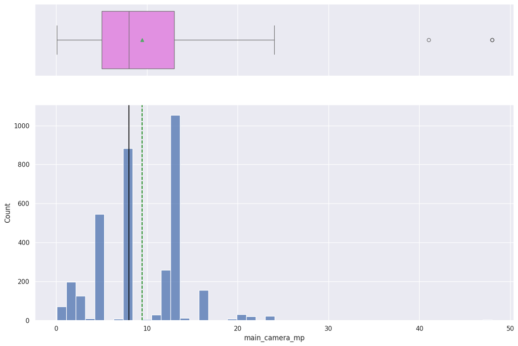

```python
histogram_boxplot(df1, "main_camera_mp")
```

**Observation:**

- After imputing missing values with the median, the distribution of main camera megapixels still shows a skew to the right, with peaks around 8MP and 13MP. The overall shape hasn't changed drastically.

**`selfie_camera_mp`**

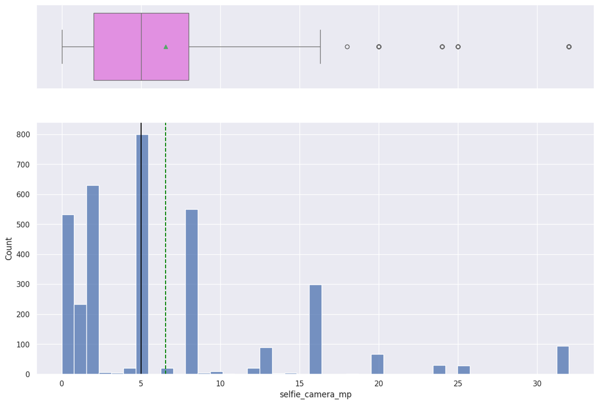

```python
histogram_boxplot(df1, "selfie_camera_mp")
```

**Observation:**

- The distribution of selfie camera megapixels remains skewed to the right after imputation.

**`int_memory`**

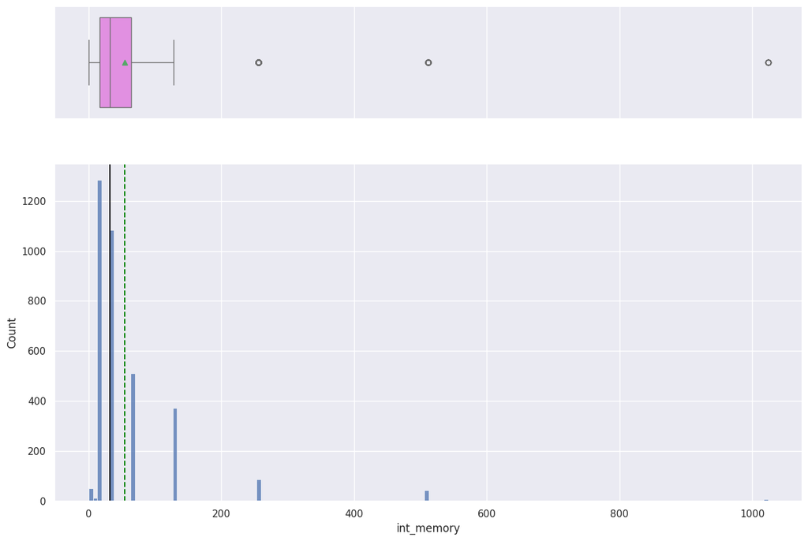

```python
histogram_boxplot(df1, "int_memory")
```

**Observation:**

- The distribution of internal memory is still highly skewed to the right, even after imputing the few missing values. The majority of devices still have lower internal memory capacities.

**`ram`**

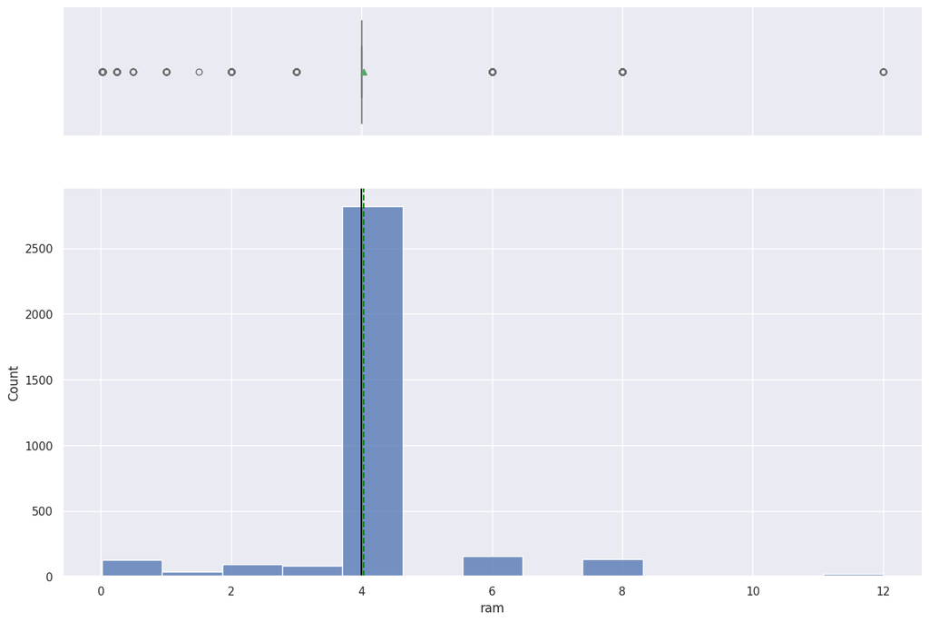

```python
histogram_boxplot(df1, "ram")
```

**Observation:**

- The distribution of RAM is still skewed to the right, with 4GB and 6GB being the most common values.

**`weight`**

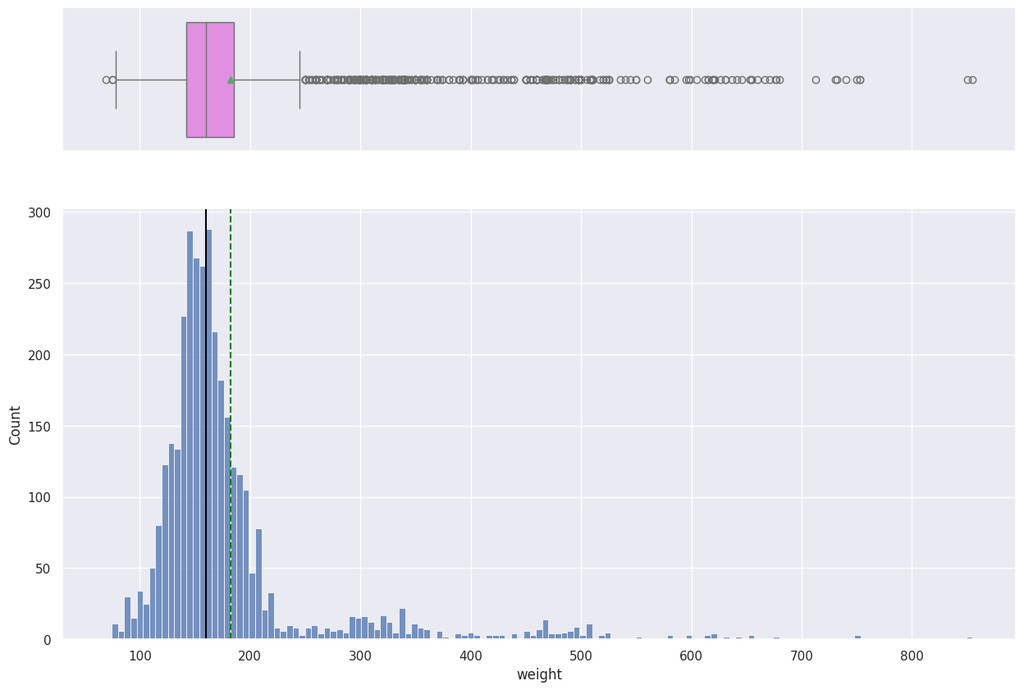

```python
histogram_boxplot(df1, "weight")
```

**Observation:**

- The distribution of weight is still slightly skewed to the right.

**`battery`**

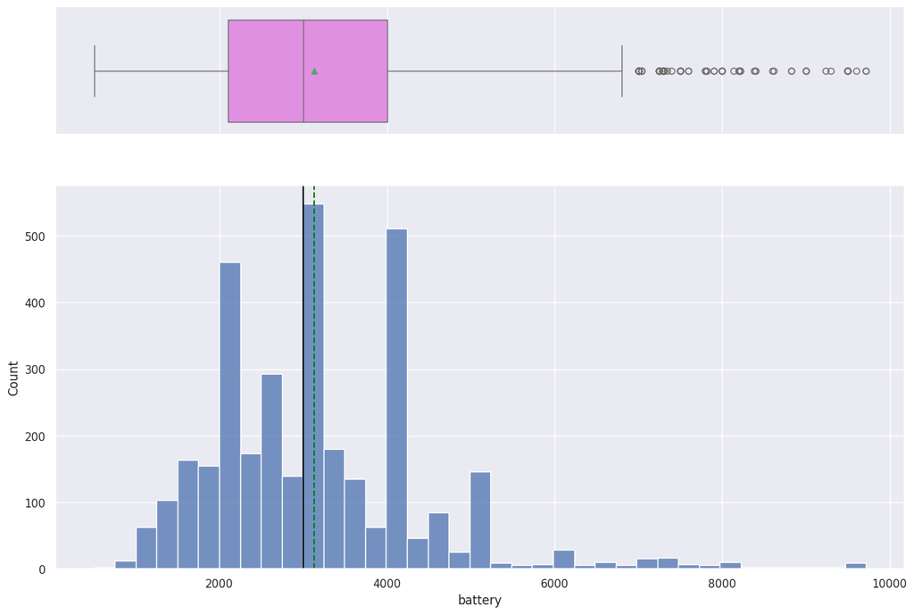

```python
histogram_boxplot(df1, "battery")
```

**Observation:**

- The distribution of battery capacity remains somewhat skewed to the right.

**`days_used`**

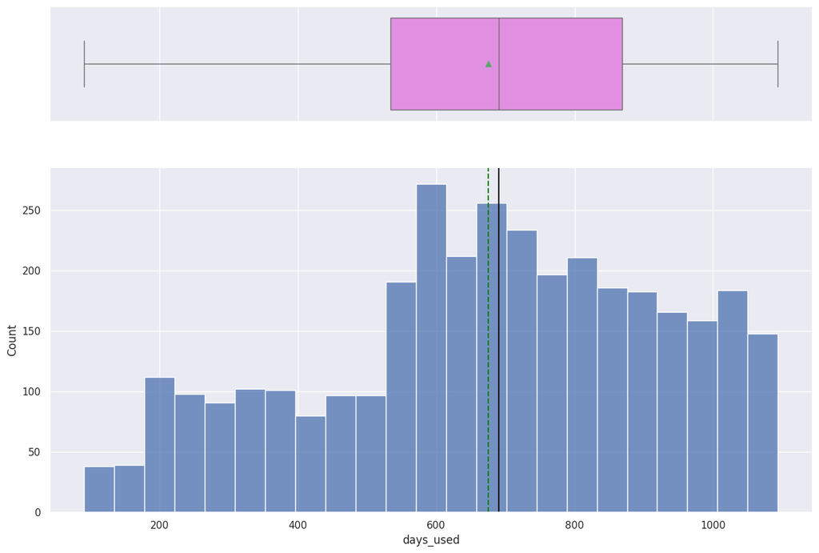

```python
histogram_boxplot(df1, "days_used")
```

**`years_since_release`**

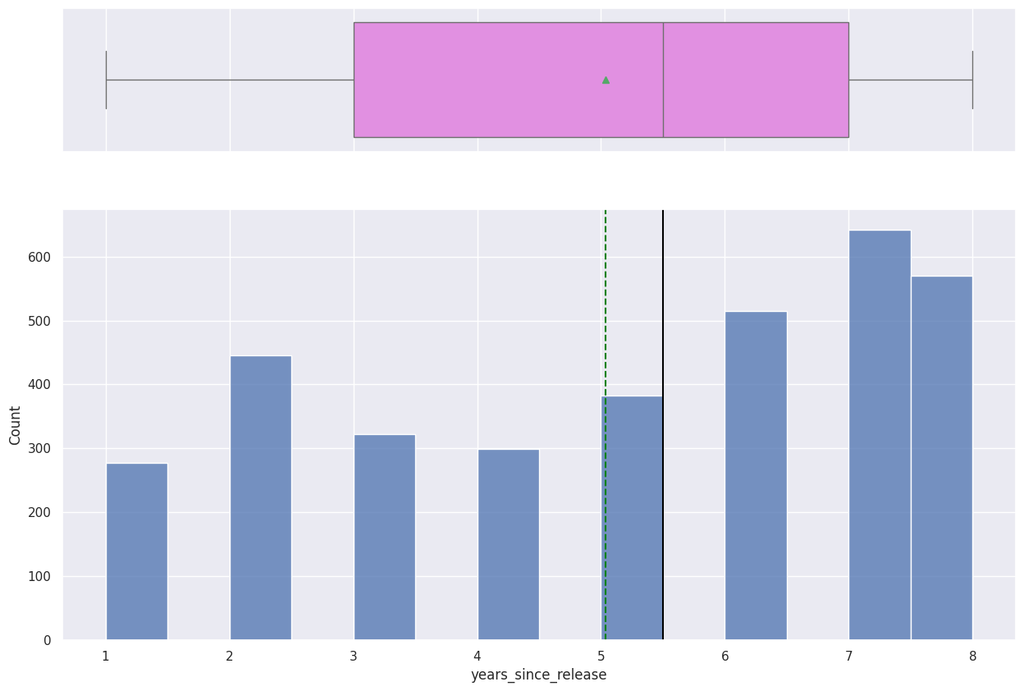

```python
histogram_boxplot(df1, "years_since_release")
```

### Correlation Matrix after Preprocessing

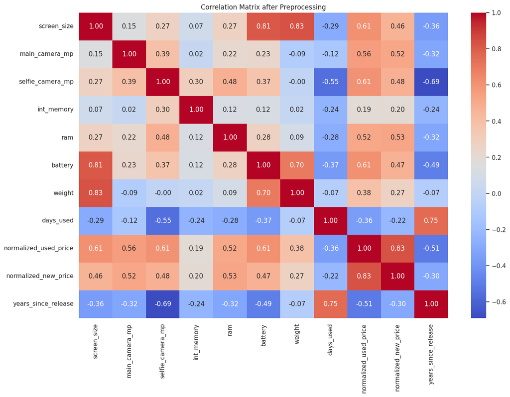

```python
plt.figure(figsize=(15, 10))
sns.heatmap(df1.corr(numeric_only=True), annot=True, cmap='coolwarm', fmt=".2f")
plt.title('Correlation Matrix after Preprocessing')
plt.show()
```

**Observation:**

- The correlation matrix now includes the `years_since_release` feature.
- `years_since_release` shows a negative correlation with `normalized_used_price`, which is expected as older devices tend to have lower used prices.
- The correlations between other numerical features and `normalized_used_price` remain similar to what was observed before preprocessing.
- We can also see negative correlation between the newly created `years_since_release` and other features like `normalized_new_price`.

## Model Building - Linear Regression

```python
# Convert boolean columns to integers
x_train = x_train.astype(int)

# Fit the OLS model
olsmodel1 = sm.OLS(y_train, x_train).fit()
print(olsmodel1.summary())
```

```
                              OLS Regression Results
=================================================================================
Dep. Variable:     normalized_used_price   R-squared:                       0.814
Model:                               OLS   Adj. R-squared:                  0.810
Method:                    Least Squares   F-statistic:                     215.8
Date:                   Sun, 20 Jul 2025   Prob (F-statistic):               0.00
Time:                           17:34:20   Log-Likelihood:                -59.818
No. Observations:                   2417   AIC:                             217.6
Df Residuals:                       2368   BIC:                             501.4
Df Model:                             48
Covariance Type:               nonrobust
=========================================================================================
                            coef    std err          t      P>|t|      [0.025      0.975]
-----------------------------------------------------------------------------------------
const                     1.9063      0.070     27.095      0.000       1.768       2.044
screen_size               0.0287      0.003      8.235      0.000       0.022       0.036
main_camera_mp            0.0263      0.002     17.002      0.000       0.023       0.029
selfie_camera_mp          0.0176      0.001     14.631      0.000       0.015       0.020
int_memory                0.0001   6.76e-05      2.181      0.029    1.49e-05       0.000
ram                       0.0400      0.005      7.310      0.000       0.029       0.051
battery                   -2e-06   7.85e-06     -0.255      0.799   -1.74e-05    1.34e-05
weight                    0.0010      0.000      7.135      0.000       0.001       0.001
days_used             -1.381e-05   3.25e-05     -0.425      0.671   -7.75e-05    4.99e-05
normalized_new_price      0.2758      0.011     25.524      0.000       0.255       0.297
years_since_release      -0.0009      0.005     -0.184      0.854      -0.010       0.009
brand_name_Alcatel        0.0334      0.052      0.647      0.517      -0.068       0.135
brand_name_Apple          0.2506      0.158      1.589      0.112      -0.059       0.560
brand_name_Asus           0.0967      0.050      1.946      0.052      -0.001       0.194
brand_name_BlackBerry     0.0257      0.075      0.341      0.733      -0.122       0.174
brand_name_Celkon        -0.1331      0.069     -1.927      0.054      -0.268       0.002
brand_name_Coolpad        0.0544      0.084      0.648      0.517      -0.110       0.219
brand_name_Gionee         0.0668      0.057      1.162      0.245      -0.046       0.180
brand_name_Google         0.1574      0.090      1.744      0.081      -0.020       0.334
brand_name_HTC            0.0229      0.050      0.456      0.649      -0.076       0.121
brand_name_Honor          0.0141      0.051      0.275      0.784      -0.087       0.115
brand_name_Huawei         0.0264      0.046      0.571      0.568      -0.064       0.117
brand_name_Infinix        0.1277      0.092      1.393      0.164      -0.052       0.307
brand_name_Karbonn       -0.0554      0.071     -0.776      0.438      -0.195       0.085
brand_name_LG             0.0360      0.047      0.766      0.444      -0.056       0.128
brand_name_Lava           0.0162      0.069      0.234      0.815      -0.120       0.152
```

[output cut: 19 more lines]

```
os_Windows               -0.0382      0.047     -0.806      0.420      -0.131       0.055
os_iOS                   -0.1962      0.160     -1.227      0.220      -0.510       0.117
4g_yes                    0.0914      0.017      5.397      0.000       0.058       0.125
5g_yes                    0.0373      0.033      1.139      0.255      -0.027       0.102
==============================================================================
Omnibus:                      148.476   Durbin-Watson:                   1.986
Prob(Omnibus):                  0.000   Jarque-Bera (JB):              405.527
Skew:                          -0.320   Prob(JB):                     8.73e-89
Kurtosis:                       4.902   Cond. No.                     1.71e+05
==============================================================================

Notes:
[1] Standard Errors assume that the covariance matrix of the errors is correctly specified.
[2] The condition number is large, 1.71e+05. This might indicate that there are
strong multicollinearity or other numerical problems.
```

1. **Adjusted. R-squared**: It reflects the fit of the model.
   - Adjusted R-squared values generally range from 0 to 1, where a higher value generally indicates a better fit, assuming certain conditions are met.
   - In our case, the value for adj. R-squared is **0.810**, which is good.
2. ***const* coefficient**: It is the Y-intercept.
   - It means that if all the predictor variable coefficients are zero, then the expected output (i.e., Y) would be equal to the *const* coefficient.
   - In our case, the value for `const` coefficient is **1.9063**
3. **Coefficient of a predictor variable**: It represents the change in the output Y due to a change in the predictor variable (everything else held constant).
   - In our case, the coefficient of `main_camera_mp` is **0.0263**.

### Model Performance Check

**Let's check the performance of the model using different metrics.**

- We will be using metric functions defined in sklearn for RMSE, MAE, and $R^2$.
- We will define a function to calculate MAPE and adjusted $R^2$.
- We will create a function which will print out all the above metrics in one go.

```python
# function to compute adjusted R-squared
def adj_r2_score(predictors, targets, predictions):
    r2 = r2_score(targets, predictions)
    n = predictors.shape[0]
    k = predictors.shape[1]
    return 1 - ((1 - r2) * (n - 1) / (n - k - 1))


# function to compute MAPE
def mape_score(targets, predictions):
    return np.mean(np.abs(targets - predictions) / targets) * 100


# function to compute different metrics to check performance of a regression model
def model_performance_regression(model, predictors, target):
    """
    Function to compute different metrics to check regression model performance

    model: regressor
    predictors: independent variables
    target: dependent variable
    """

    # predicting using the independent variables
    pred = model.predict(predictors)

    r2 = r2_score(target, pred)  # to compute R-squared
    adjr2 = adj_r2_score(predictors, target, pred)  # to compute adjusted R-squared
    rmse = np.sqrt(mean_squared_error(target, pred))  # to compute RMSE
    mae = mean_absolute_error(target, pred)  # to compute MAE
    mape = mape_score(target, pred)  # to compute MAPE

    # creating a dataframe of metrics
    df_perf = pd.DataFrame(
        {
            "RMSE": rmse,
            "MAE": mae,
            "R-squared": r2,
            "Adj. R-squared": adjr2,
            "MAPE": mape,
        },
        index=[0],
    )

    return df_perf
```

```python
# checking model performance on train set (seen 70% data)
print("Training Performance\n")
olsmodel1_train_perf = model_performance_regression(olsmodel1, x_train, y_train)
olsmodel1_train_perf
```

```
Training Performance
```

|  | RMSE | MAE | R-squared | Adj. R-squared | MAPE |
| --- | --- | --- | --- | --- | --- |
| 0 | 0.248034 | 0.190321 | 0.813959 | 0.810108 | 4.548741 |

```python
# checking model performance on test set (seen 30% data)
print("Test Performance\n")
olsmodel1_test_perf = model_performance_regression(olsmodel1, x_test, y_test)
olsmodel1_test_perf
```

```
Test Performance
```

|  | RMSE | MAE | R-squared | Adj. R-squared | MAPE |
| --- | --- | --- | --- | --- | --- |
| 0 | 0.297822 | 0.226781 | 0.768742 | 0.757261 | 5.759077 |

## Checking Linear Regression Assumptions

We will be checking the following Linear Regression assumptions:

1. **No Multicollinearity**
2. **Linearity of variables**
3. **Independence of error terms**
4. **Normality of error terms**
5. **No Heteroscedasticity**

### TEST FOR MULTICOLLINEARITY

- We will test for multicollinearity using VIF.
- **General Rule of thumb**:
  - If VIF is 1 then there is no correlation between the $k$th predictor and the remaining predictor variables.
  - If VIF exceeds 5 or is close to exceeding 5, we say there is moderate multicollinearity.
  - If VIF is 10 or exceeding 10, it shows signs of high multicollinearity.

Let's define a function to check VIF.

```python
#Let's define a function to check VIF.

def checking_vif(predictors):
    vif = pd.DataFrame()
    vif["feature"] = predictors.columns

    # calculating VIF for each feature
    vif["VIF"] = [
        variance_inflation_factor(predictors.values, i)
        for i in range(len(predictors.columns))
    ]
    return vif
```

```python
checking_vif(x_train)
```

|  | feature | VIF |
| --- | --- | --- |
| 0 | const | 190.543874 |
| 1 | screen_size | 6.922771 |
| 2 | main_camera_mp | 2.041317 |
| 3 | selfie_camera_mp | 2.807208 |
| 4 | int_memory | 1.260569 |
| 5 | ram | 2.133207 |
| 6 | battery | 4.097420 |
| 7 | weight | 5.844239 |
| 8 | days_used | 2.558063 |
| 9 | normalized_new_price | 2.309225 |
| 10 | years_since_release | 4.650909 |
| 11 | brand_name_Alcatel | 2.799933 |
| 12 | brand_name_Apple | 10.185344 |
| 13 | brand_name_Asus | 3.223566 |
| 14 | brand_name_BlackBerry | 1.616214 |
| 15 | brand_name_Celkon | 1.730585 |
| 16 | brand_name_Coolpad | 1.339964 |
| 17 | brand_name_Gionee | 2.120994 |
| 18 | brand_name_Google | 1.292549 |
| 19 | brand_name_HTC | 3.187926 |
| 20 | brand_name_Honor | 3.210710 |
| 21 | brand_name_Huawei | 5.414205 |
| 22 | brand_name_Infinix | 1.332118 |
| 23 | brand_name_Karbonn | 1.530592 |
| 24 | brand_name_LG | 4.613596 |
| 25 | brand_name_Lava | 1.593330 |
| 26 | brand_name_Lenovo | 4.144050 |
| 27 | brand_name_Meizu | 2.337228 |
| 28 | brand_name_Micromax | 3.227640 |
| 29 | brand_name_Microsoft | 1.703780 |
| 30 | brand_name_Motorola | 3.249074 |
| 31 | brand_name_Nokia | 3.407181 |
| 32 | brand_name_OnePlus | 1.480622 |
| 33 | brand_name_Oppo | 3.536987 |
| 34 | brand_name_Others | 9.127791 |
| 35 | brand_name_Panasonic | 1.948176 |
| 36 | brand_name_Realme | 1.932759 |
| 37 | brand_name_Samsung | 7.078013 |
| 38 | brand_name_Sony | 2.502171 |
| 39 | brand_name_Spice | 1.623647 |
| 40 | brand_name_Vivo | 3.244497 |
| 41 | brand_name_XOLO | 1.873513 |
| 42 | brand_name_Xiaomi | 3.425833 |
| 43 | brand_name_ZTE | 3.599424 |
| 44 | os_Others | 1.714726 |
| 45 | os_Windows | 1.611209 |
| 46 | os_iOS | 9.283611 |
| 47 | 4g_yes | 2.432589 |
| 48 | 5g_yes | 1.856590 |

- There are multiple columns with 5 and 10 VIF values, indicating presence of moderate multicollinearity
- We will systematically drop numerical columns with VIF > 5
- We will ignore the VIF values for dummy variables and the constant (intercept)

### Removing Multicollinearity (if needed)

To remove multicollinearity

1. Drop every column one by one that has a VIF score greater than 5.
2. Look at the adjusted R-squared and RMSE of all these models.
3. Drop the variable that makes the least change in adjusted R-squared.
4. Check the VIF scores again.
5. Continue till you get all VIF scores under 5.

Let's define a function that will help us do this.

```python
def treating_multicollinearity(predictors, target, high_vif_columns):
    """
    Checking the effect of dropping the columns showing high multicollinearity
    on model performance (adj. R-squared and RMSE)

    predictors: independent variables
    target: dependent variable
    high_vif_columns: columns having high VIF
    """
    # empty lists to store adj. R-squared and RMSE values
    adj_r2 = []
    rmse = []

    # build ols models by dropping one of the high VIF columns at a time
    # store the adjusted R-squared and RMSE in the lists defined previously
    for cols in high_vif_columns:
        # defining the new train set
        train = predictors.loc[:, ~predictors.columns.str.startswith(cols)]

        # create the model
        olsmodel = sm.OLS(target, train).fit()

        # adding adj. R-squared and RMSE to the lists
        adj_r2.append(olsmodel.rsquared_adj)
        rmse.append(np.sqrt(olsmodel.mse_resid))

    # creating a dataframe for the results
    temp = pd.DataFrame(
        {
            "col": high_vif_columns,
            "Adj. R-squared after_dropping col": adj_r2,
            "RMSE after dropping col": rmse,
        }
    ).sort_values(by="Adj. R-squared after_dropping col", ascending=False)
    temp.reset_index(drop=True, inplace=True)

    return temp
```

```python
# columns with high VIF
col_list = ['screen_size', 'weight']

res = treating_multicollinearity(x_train, y_train, col_list)
res
```

|  | col | Adj. R-squared after_dropping col | RMSE after dropping col |
| --- | --- | --- | --- |
| 0 | weight | 0.806189 | 0.253213 |
| 1 | screen_size | 0.804835 | 0.254096 |

```python
col_to_drop = res.loc[0, "col"]
x_train2 = x_train.loc[:, ~x_train.columns.str.startswith(col_to_drop)]
x_test2 = x_test.loc[:, ~x_test.columns.str.startswith(col_to_drop)] # specify the test data from which to drop the column specified

# Check VIF now
vif = checking_vif(x_train2)
print("VIF after dropping ", col_to_drop)
vif
```

```
VIF after dropping  weight
```

|  | feature | VIF |
| --- | --- | --- |
| 0 | const | 177.977343 |
| 1 | screen_size | 3.490387 |
| 2 | main_camera_mp | 1.997436 |
| 3 | selfie_camera_mp | 2.782261 |
| 4 | int_memory | 1.260491 |
| 5 | ram | 2.127114 |
| 6 | battery | 3.651827 |
| 7 | days_used | 2.540241 |
| 8 | normalized_new_price | 2.308992 |
| 9 | years_since_release | 4.510639 |
| 10 | brand_name_Alcatel | 2.798864 |
| 11 | brand_name_Apple | 10.181578 |
| 12 | brand_name_Asus | 3.223020 |
| 13 | brand_name_BlackBerry | 1.615922 |
| 14 | brand_name_Celkon | 1.730157 |
| 15 | brand_name_Coolpad | 1.339964 |
| 16 | brand_name_Gionee | 2.120313 |
| 17 | brand_name_Google | 1.292539 |
| 18 | brand_name_HTC | 3.187178 |
| 19 | brand_name_Honor | 3.205025 |
| 20 | brand_name_Huawei | 5.413755 |
| 21 | brand_name_Infinix | 1.328747 |
| 22 | brand_name_Karbonn | 1.530291 |
| 23 | brand_name_LG | 4.613360 |
| 24 | brand_name_Lava | 1.592296 |
| 25 | brand_name_Lenovo | 4.143755 |
| 26 | brand_name_Meizu | 2.337161 |
| 27 | brand_name_Micromax | 3.226931 |
| 28 | brand_name_Microsoft | 1.702694 |
| 29 | brand_name_Motorola | 3.248160 |
| 30 | brand_name_Nokia | 3.406349 |
| 31 | brand_name_OnePlus | 1.480547 |
| 32 | brand_name_Oppo | 3.536271 |
| 33 | brand_name_Others | 9.107638 |
| 34 | brand_name_Panasonic | 1.947211 |
| 35 | brand_name_Realme | 1.929939 |
| 36 | brand_name_Samsung | 7.077891 |
| 37 | brand_name_Sony | 2.500202 |
| 38 | brand_name_Spice | 1.623393 |
| 39 | brand_name_Vivo | 3.240885 |
| 40 | brand_name_XOLO | 1.872005 |
| 41 | brand_name_Xiaomi | 3.423330 |
| 42 | brand_name_ZTE | 3.599222 |
| 43 | os_Others | 1.639521 |
| 44 | os_Windows | 1.611005 |
| 45 | os_iOS | 9.263830 |
| 46 | 4g_yes | 2.421858 |
| 47 | 5g_yes | 1.854530 |

- We have dealt with multicollinearity in the data

### Dropping high p-value variables (if needed)

- We will drop the predictor variables having a p-value greater than 0.05 as they do not significantly impact the target variable.
- But sometimes p-values change after dropping a variable. So, we'll not drop all variables at once.
- Instead, we will do the following:
  - Build a model, check the p-values of the variables, and drop the column with the highest p-value.
  - Create a new model without the dropped feature, check the p-values of the variables, and drop the column with the highest p-value.
  - Repeat the above two steps till there are no columns with p-value > 0.05.

The above process can also be done manually by picking one variable at a time that has a high p-value, dropping it, and building a model again. But that might be a little tedious and using a loop will be more efficient.

```python
# initial list of columns
predictors = x_train2.copy() #code to check for p-values on the right dataset
cols = predictors.columns.tolist()

# setting an initial max p-value
max_p_value = 1

while len(cols) > 0:
    # defining the train set
    x_train_aux = predictors[cols]

    # fitting the model
    model = sm.OLS(y_train, x_train_aux).fit()

    # getting the p-values and the maximum p-value
    p_values = model.pvalues
    max_p_value = max(p_values)

    # name of the variable with maximum p-value
    feature_with_p_max = p_values.idxmax()

    if max_p_value > 0.05:
        cols.remove(feature_with_p_max)
    else:
        break

selected_features = cols
print(selected_features)
```

```
['const', 'screen_size', 'main_camera_mp', 'selfie_camera_mp', 'int_memory', 'ram', 'battery', 'normalized_new_price', 'brand_name_Asus', 'brand_name_Celkon', 'brand_name_Micromax', 'brand_name_Nokia', '4g_yes']
```

```python
# specify the train data from which to select the specified columns
x_train3 = x_train2[selected_features]

# specify the test data from which to select the specified columns
x_test3 = x_test2[selected_features]
```

```python
#fit OLS() on updated dataset (no multicollinearity and no insignificant predictors)
olsmodel2 = sm.OLS(y_train, x_train3).fit()
print(olsmodel2.summary())
```

```
                              OLS Regression Results
=================================================================================
Dep. Variable:     normalized_used_price   R-squared:                       0.807
Model:                               OLS   Adj. R-squared:                  0.807
Method:                    Least Squares   F-statistic:                     840.2
Date:                   Sun, 20 Jul 2025   Prob (F-statistic):               0.00
Time:                           17:37:30   Log-Likelihood:                -101.24
No. Observations:                   2417   AIC:                             228.5
Df Residuals:                       2404   BIC:                             303.7
Df Model:                             12
Covariance Type:               nonrobust
========================================================================================
                           coef    std err          t      P>|t|      [0.025      0.975]
----------------------------------------------------------------------------------------
const                    1.7856      0.039     45.533      0.000       1.709       1.862
screen_size              0.0458      0.002     19.615      0.000       0.041       0.050
main_camera_mp           0.0237      0.001     16.736      0.000       0.021       0.026
selfie_camera_mp         0.0162      0.001     16.662      0.000       0.014       0.018
int_memory               0.0001   6.61e-05      2.167      0.030    1.36e-05       0.000
ram                      0.0412      0.005      8.818      0.000       0.032       0.050
battery               1.871e-05   7.07e-06      2.645      0.008    4.84e-06    3.26e-05
normalized_new_price     0.2869      0.010     28.741      0.000       0.267       0.306
brand_name_Asus          0.0747      0.028      2.650      0.008       0.019       0.130
brand_name_Celkon       -0.1373      0.055     -2.477      0.013      -0.246      -0.029
brand_name_Micromax     -0.0585      0.029     -2.016      0.044      -0.115      -0.002
brand_name_Nokia         0.0741      0.030      2.482      0.013       0.016       0.133
4g_yes                   0.0836      0.015      5.682      0.000       0.055       0.112
==============================================================================
Omnibus:                      126.511   Durbin-Watson:                   1.996
Prob(Omnibus):                  0.000   Jarque-Bera (JB):              306.900
Skew:                          -0.300   Prob(JB):                     2.28e-67
Kurtosis:                       4.639   Cond. No.                     3.74e+04
==============================================================================

Notes:
[1] Standard Errors assume that the covariance matrix of the errors is correctly specified.
[2] The condition number is large, 3.74e+04. This might indicate that there are
strong multicollinearity or other numerical problems.
```

```python
# checking model performance on train set (seen 70% data)
print("Training Performance\n")
# check performance on train data
olsmodel2_train_perf = model_performance_regression(olsmodel2, x_train3, y_train)
olsmodel2_train_perf
```

```
Training Performance
```

|  | RMSE | MAE | R-squared | Adj. R-squared | MAPE |
| --- | --- | --- | --- | --- | --- |
| 0 | 0.252321 | 0.194646 | 0.807472 | 0.806431 | 4.6467 |

```python
# checking model performance on test set (seen 30% data)
print("Test Performance\n")
# check the performance on test data
olsmodel2_test_perf = model_performance_regression(olsmodel2, x_test3, y_test)
olsmodel2_test_perf
```

```
Test Performance
```

|  | RMSE | MAE | R-squared | Adj. R-squared | MAPE |
| --- | --- | --- | --- | --- | --- |
| 0 | 0.308254 | 0.236588 | 0.752257 | 0.749108 | 5.995745 |

**Observations**

**Now we'll check the rest of the assumptions on *olsmod2*.**

2. **Linearity of variables**
3. **Independence of error terms**
4. **Normality of error terms**
5. **No Heteroscedasticity**

### TEST FOR LINEARITY AND INDEPENDENCE

- We will test for linearity and independence by making a plot of fitted values vs residuals and checking for patterns.
- If there is no pattern, then we say the model is linear and residuals are independent.
- Otherwise, the model is showing signs of non-linearity and residuals are not independent.

```python
# let us create a dataframe with actual, fitted and residual values
df_pred = pd.DataFrame()

df_pred["Actual Values"] = y_train  # actual values
df_pred["Fitted Values"] = olsmodel2.fittedvalues  # predicted values
df_pred["Residuals"] = olsmodel2.resid  # residuals

df_pred.head()
```

|  | Actual Values | Fitted Values | Residuals |
| --- | --- | --- | --- |
| 2343 | 4.326514 | 4.365640 | -0.039126 |
| 3353 | 5.327536 | 5.323156 | 0.004380 |
| 590 | 3.983972 | 4.065072 | -0.081100 |
| 2663 | 4.782898 | 4.594858 | 0.188040 |
| 1336 | 3.694613 | 3.834210 | -0.139597 |

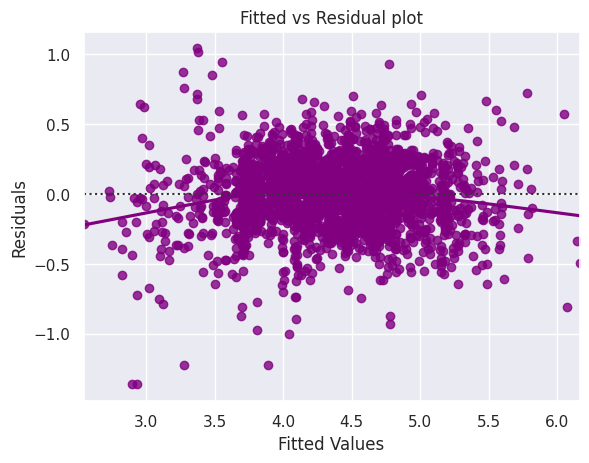

```python
# let's plot the fitted values vs residuals

sns.residplot(
    data=df_pred, x="Fitted Values", y="Residuals", color="purple", lowess=True
)
plt.xlabel("Fitted Values")
plt.ylabel("Residuals")
plt.title("Fitted vs Residual plot")
plt.show()
```

- The scatter plot shows the distribution of residuals (errors) vs fitted values (predicted values).
- **We see no pattern in the plot above. Hence, the assumptions of linearity and independence are satisfied.**

### TEST FOR NORMALITY

- We will test for normality by checking the distribution of residuals, by checking the Q-Q plot of residuals, and by using the Shapiro-Wilk test.
- If the residuals follow a normal distribution, they will make a straight line plot, otherwise not.
- If the p-value of the Shapiro-Wilk test is greater than 0.05, we can say the residuals are normally distributed.

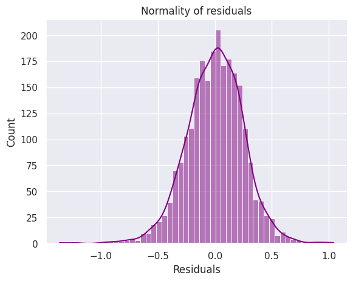

```python
# plot the distribution of residuals
sns.histplot(data=df_pred, x="Residuals", kde=True, color="purple")
plt.xlabel("Residuals")
plt.title("Normality of residuals")
plt.show()
```

- The histogram of residuals does have a bell shape.
- Let's check the Q-Q plot.

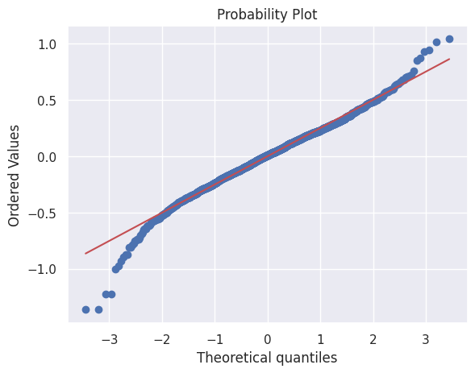

```python
import pylab
import scipy.stats as stats

# check Q-Q plot
stats.probplot(df_pred["Residuals"], dist="norm", plot=pylab)
pylab.show()
plt.show()
```

- The residuals more or less follow a straight line except for the tails.
- Let's check the results of the Shapiro-Wilk test.

```python
# apply the Shapiro-Wilks test
stats.shapiro(df_pred["Residuals"])
```

```
ShapiroResult(statistic=np.float64(0.9864246204910342), pvalue=np.float64(2.0505839021867982e-14))
```

- Since p-value < 0.05, the residuals are not normal as per the Shapiro-Wilk test.
- Though, the residuals are not normal.
- However, as an approximation, we can accept this distribution as close to being normal.
- **So, the assumption is satisfied.**

### TEST FOR HOMOSCEDASTICITY

- We will test for homoscedasticity by using the goldfeldquandt test.
- If we get a p-value greater than 0.05, we can say that the residuals are homoscedastic. Otherwise, they are heteroscedastic.

```python
import statsmodels.stats.api as sms
from statsmodels.compat import lzip

name = ["F statistic", "p-value"]
# apply the Goldfeldquandt test
test = sms.het_goldfeldquandt(df_pred["Residuals"], x_train3)
lzip(name, test)
```

```
[('F statistic', np.float64(0.9184818483590235)),
 ('p-value', np.float64(0.9291524002940186))]
```

**Since p-value > 0.05, we can say that the residuals are homoscedastic. So, this assumption is satisfied.**

## Predictions on test data

```python
# predictions on the test set
y_pred = olsmodel2.predict(x_test3)

df_test = pd.DataFrame({"Actual": y_test, "Predicted": y_pred})
df_test.head()
```

|  | Actual | Predicted |
| --- | --- | --- |
| 3063 | 4.345233 | 4.455997 |
| 2587 | 5.114034 | 5.30826 |
| 2831 | 4.933898 | 4.992581 |
| 3381 | 5.331027 | 5.955806 |
| 955 | 2.315501 | 2.853052 |

- We can observe here that our model has returned pretty good prediction results, and the actual and predicted values are comparable

## Final Model

```python
x_train_final = x_train3.copy()
x_test_final = x_test3.copy()
```

```python
#  fit the final model
olsmodel_final = sm.OLS(y_train, x_train_final).fit()
print(olsmodel_final.summary())
```

```
                              OLS Regression Results
=================================================================================
Dep. Variable:     normalized_used_price   R-squared:                       0.807
Model:                               OLS   Adj. R-squared:                  0.807
Method:                    Least Squares   F-statistic:                     840.2
Date:                   Sun, 20 Jul 2025   Prob (F-statistic):               0.00
Time:                           17:40:06   Log-Likelihood:                -101.24
No. Observations:                   2417   AIC:                             228.5
Df Residuals:                       2404   BIC:                             303.7
Df Model:                             12
Covariance Type:               nonrobust
========================================================================================
                           coef    std err          t      P>|t|      [0.025      0.975]
----------------------------------------------------------------------------------------
const                    1.7856      0.039     45.533      0.000       1.709       1.862
screen_size              0.0458      0.002     19.615      0.000       0.041       0.050
main_camera_mp           0.0237      0.001     16.736      0.000       0.021       0.026
selfie_camera_mp         0.0162      0.001     16.662      0.000       0.014       0.018
int_memory               0.0001   6.61e-05      2.167      0.030    1.36e-05       0.000
ram                      0.0412      0.005      8.818      0.000       0.032       0.050
battery               1.871e-05   7.07e-06      2.645      0.008    4.84e-06    3.26e-05
normalized_new_price     0.2869      0.010     28.741      0.000       0.267       0.306
brand_name_Asus          0.0747      0.028      2.650      0.008       0.019       0.130
brand_name_Celkon       -0.1373      0.055     -2.477      0.013      -0.246      -0.029
brand_name_Micromax     -0.0585      0.029     -2.016      0.044      -0.115      -0.002
brand_name_Nokia         0.0741      0.030      2.482      0.013       0.016       0.133
4g_yes                   0.0836      0.015      5.682      0.000       0.055       0.112
==============================================================================
Omnibus:                      126.511   Durbin-Watson:                   1.996
Prob(Omnibus):                  0.000   Jarque-Bera (JB):              306.900
Skew:                          -0.300   Prob(JB):                     2.28e-67
Kurtosis:                       4.639   Cond. No.                     3.74e+04
==============================================================================

Notes:
[1] Standard Errors assume that the covariance matrix of the errors is correctly specified.
[2] The condition number is large, 3.74e+04. This might indicate that there are
strong multicollinearity or other numerical problems.
```

```python
# checking model performance on train set (seen 70% data)
print("Training Performance\n")
olsmodel_final_train_perf = model_performance_regression(olsmodel_final, x_train3, y_train)
olsmodel_final_train_perf
```

```
Training Performance
```

|  | RMSE | MAE | R-squared | Adj. R-squared | MAPE |
| --- | --- | --- | --- | --- | --- |
| 0 | 0.252321 | 0.194646 | 0.807472 | 0.806431 | 4.6467 |

```python
# checking model performance on test set (seen 30% data)
print("Test Performance\n")
olsmodel_final_test_perf = model_performance_regression(olsmodel_final, x_test3, y_test)
olsmodel_final_test_perf
```

```
Test Performance
```

|  | RMSE | MAE | R-squared | Adj. R-squared | MAPE |
| --- | --- | --- | --- | --- | --- |
| 0 | 0.308254 | 0.236588 | 0.752257 | 0.749108 | 5.995745 |